# Using spectator - worked examples

# Introduction

The `spectator` package for R was developed to allow access to the ‘[Spectator Earth](https://spectator.earth/)’ API from R. Spectator Earth offers a Web app providing Earth Observation imagery, mainly from open data satellites like the Sentinel and the Landsat family. These features are also exposed through an API, and the goal of the `spectator` package is to provide easy access to this functionality from R.

The main functions allow to retrieve the acquisition plans for Sentinel-1, Sentinel-2, Landsat-8 and Landsat-9 satellites and to get the past or (near)future overpasses over an area of interest for these satellites. It is also possible to search the archive for available images over the area of interest for a given (past) period, get the URL links to download the whole image tiles, or alternatively to download the image for just the area of interest based on selected spectral bands.

One can also get a current position and trajectory for a much larger set of satellites.

Other functions might be added in subsequent releases of the package.

# API key

# Satellites

We can get the list of all the satellites referenced in the [Spectator Earth](https://spectator.earth/) database and their current positions.

```r
pos <- GetAllSatellites(positions = TRUE)
head(pos, n = 20L)
```

|  | id | name | norad_id | sensors | open | platform | geometry |
| --- | --- | --- | --- | --- | --- | --- | --- |
| 1 | 36 | ALOS-2 | 39766 | SAR | FALSE | NA |  |
| 2 | 25 | Aqua | 27424 | OPTICAL | TRUE | NA |  |
| 3 | 63 | CartoSat 2 (IRS P7, CartoSat 2AT) | 29710 | UNKNOWN | FALSE | NA |  |
| 4 | 65 | CartoSat 2B | 36795 | UNKNOWN | FALSE | NA |  |
| 5 | 66 | CartoSat 2C | 41599 | UNKNOWN | FALSE | NA |  |
| 6 | 67 | CartoSat 2D | 41948 | UNKNOWN | FALSE | NA |  |
| 7 | 68 | CartoSat 2E | 42767 | UNKNOWN | FALSE | NA |  |
| 8 | 69 | CartoSat 2F | 43111 | UNKNOWN | FALSE | NA |  |
| 9 | 38 | CBERS-4 | 40336 | OPTICAL | TRUE | NA |  |
| 10 | 81 | Coriolis (Windsat) | 27640 | UNKNOWN | FALSE | NA |  |

[output cut: 10 more lines]

We can now plot the current positions of all the satellites on the world map. We shall show the open data satellites in green, and all the others in red. We can also add satellite names as labels. In order to be able to read them, we will shift labels up a little bit.

```r
# we need these packages
library(sf)
```

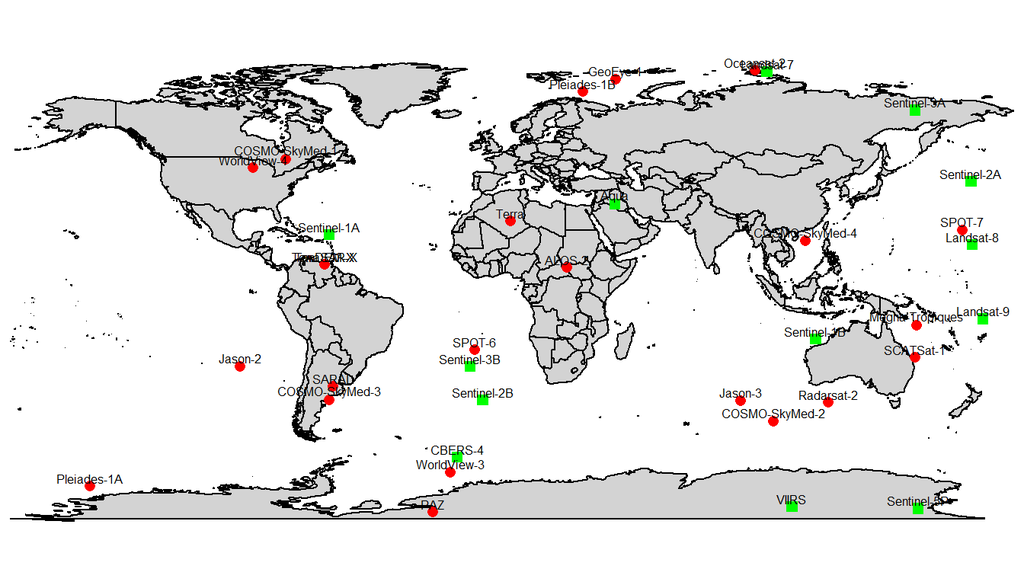

```r
library(maps)
maps::map("world", fill = TRUE, col = "lightgrey", mar = rep(0.0, 4L))
plot(sf::st_geometry(subset(pos, open == TRUE)), add = TRUE, col = "green", pch = 15)
plot(sf::st_geometry(subset(pos, open == FALSE)), add = TRUE, col = "red", pch = 16)
xy <- sf::st_coordinates(pos)
xy[, 2] <- xy[, 2] + 3
text(xy, labels = pos$name, cex = 0.5)
```

# Trajectories

It is possible to get the current trajectory and the current position for a selected satellite (here *SPOT-7*).

```r
sat <- "SPOT-7"
traj <- GetTrajectory(satellite = sat)
pos1 <- GetSatellite(satellite = sat, positions = TRUE)
```

These can be plotted on the world map, trajectory in red and the current position in green.

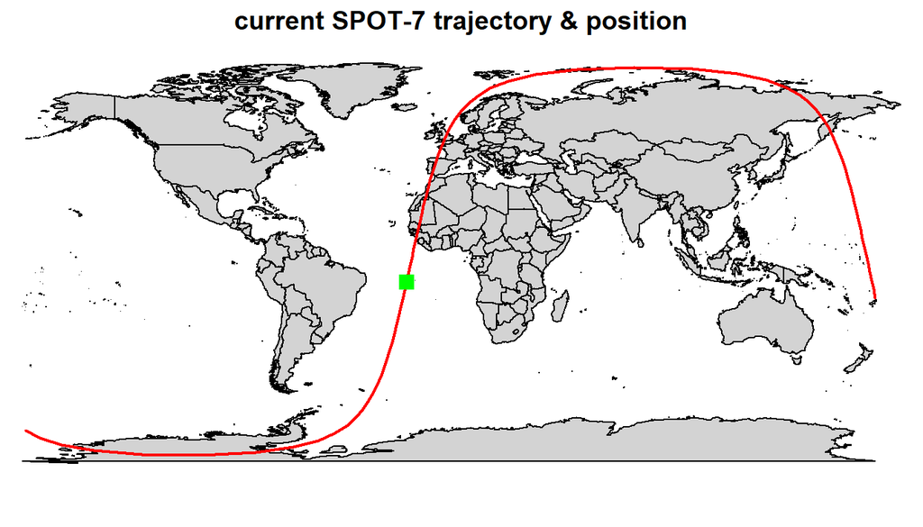

```r
maps::map("world", fill = TRUE, col = "lightgrey", mar = c(0.5, 0.5, 3, 0.5))
plot(sf::st_geometry(traj), lwd = 2, col = "red", add = TRUE)
plot(sf::st_geometry(pos1), pch = 15, col = "green", cex = 1.5, add = TRUE)
title(main = sprintf("current %s trajectory & position", sat))
```

# Acquisition plans

This functionality is available only for Sentinel-1, Sentinel-2, Landsat-8 and Landsat-9 satellites. It is based on the files provided by ESA (Sentinel-1, Sentinel-2) and USGS (Landsat-8, Landsat-9), For Sentinels the acquisition plans usually have a range of 10-15 days, while for Landsat-8 and Landsat-9 it is 2-4 days. The time range that you can view is limited to 24 hours due to a large number of polygons. More information is available from the ESA and USGS web pages for [Sentinel-1](https://sentinel.esa.int/web/sentinel/missions/sentinel-1/observation-scenario/acquisition-segments), [Sentinel-2](https://sentinel.esa.int/web/sentinel/missions/sentinel-2/acquisition-plans), and [Landsat-8 and Landsat-9](https://landsat.usgs.gov/landsat_acq).

To begin with, we shall retrieve the acquisition plans for all eligible satellites for today (default value). We shall limit the dataset to the first 100 records, because of the size of the full dataset (> 1000 rows).

```r
plans <- head(GetAcquisitionPlan(), n = 100L)
plans
```

|  | begin_time | polarisation | id | observation_duration | geometry | orbit_relative | mode | row | scenes | satellite | path | datatake_id | swath | end_time | orbit_absolute | station | timeliness |
| --- | --- | --- | --- | --- | --- | --- | --- | --- | --- | --- | --- | --- | --- | --- | --- | --- | --- |
| 1 | 2021-11-28 00:04:29 | NA | 24695-4 | 21648 |  | 73 | NOBS | NA | 6 | Sentinel-2B | NA | NA | NA | 2021-11-28 00:04:51 | 24695 | EDRS-A | NOMINAL |
| 2 | 2021-11-28 00:04:29 | NA | 24695-4 | 21648 |  | 73 | NOBS | NA | 6 | Sentinel-2B | NA | NA | NA | 2021-11-28 00:04:51 | 24695 | EDRS-A | NOMINAL |
| 3 | 2021-11-28 00:07:25 | NA | 24695-5 | 165968 |  | 73 | NOBS | NA | 46 | Sentinel-2B | NA | NA | NA | 2021-11-28 00:10:11 | 24695 | EDRS-A | NOMINAL |
| 4 | 2021-11-28 00:07:25 | NA | 24695-5 | 165968 |  | 73 | NOBS | NA | 46 | Sentinel-2B | NA | NA | NA | 2021-11-28 00:10:11 | 24695 | EDRS-A | NOMINAL |
| 5 | 2021-11-28 00:11:04 | NA | 24695-6 | 479864 |  | 73 | NOBS | NA | 133 | Sentinel-2B | NA | NA | NA | 2021-11-28 00:19:03 | 24695 | SGS_/EDRS-A | NOMINAL |
| 6 | 2021-11-28 00:11:04 | NA | 24695-6 | 479864 |  | 73 | NOBS | NA | 133 | Sentinel-2B | NA | NA | NA | 2021-11-28 00:19:03 | 24695 | SGS_/EDRS-A | NOMINAL |
| 7 | 2021-11-28 00:24:53 | NA | 24695-7 | 176792 |  | 73 | NOBS | NA | 49 | Sentinel-2B | NA | NA | NA | 2021-11-28 00:27:50 | 24695 | SGS_ | NOMINAL |
| 8 | 2021-11-28 00:24:53 | NA | 24695-7 | 176792 |  | 73 | NOBS | NA | 49 | Sentinel-2B | NA | NA | NA | 2021-11-28 00:27:50 | 24695 | SGS_ | NOMINAL |
| 9 | 2021-11-28 00:26:40 | DV | NA | NA |  | 92 | IW | NA | NA | Sentinel-1A | NA | 4D69D | NA | 2021-11-28 00:33:45 | 40764 | NA | NA |
| 10 | 2021-11-28 00:26:40 | DV | NA | NA |  | 92 | IW | NA | NA | Sentinel-1A | NA | 4D699 | NA | 2021-11-28 00:33:45 | 40764 | NA | NA |

[output cut: 90 more lines]

You can explore the content of the data frame, you’ll see that the attributes of the output will vary, depending on the satellite. For more information check out acquisition plan file descriptions at the above-mentioned web pages.  
We can now focus on Sentinel 2 satellites, and look for the acquisition plans for the day after tomorrow.

```r
sat <- c("Sentinel-2A", "Sentinel-2B")
day <- "2021-11-30"
plan <- GetAcquisitionPlan(satellites = sat, date = day)
head(plan)
```

|  | timeliness | station | orbit_absolute | end_time | satellite | scenes | id | mode | orbit_relative | observation_duration | begin_time | geometry |
| --- | --- | --- | --- | --- | --- | --- | --- | --- | --- | --- | --- | --- |
| 1 | NOMINAL | EDRS-A | 24731 | 2021-11-30 12:14:19 | Sentinel-2B | 8 | 24731-1 | NOBS | 109 | 28864 | 2021-11-30 12:13:50 |  |
| 2 | NOMINAL | EDRS-A | 24731 | 2021-11-30 12:15:43 | Sentinel-2B | 6 | 24731-2 | NOBS | 109 | 21648 | 2021-11-30 12:15:22 |  |
| 3 | NOMINAL | EDRS-A | 24731 | 2021-11-30 12:27:12 | Sentinel-2B | 7 | 24731-3 | NOBS | 109 | 25256 | 2021-11-30 12:26:47 |  |
| 4 | NOMINAL | SGS_ | 24731 | 2021-11-30 12:55:05 | Sentinel-2B | 101 | 24731-4 | NOBS | 109 | 364408 | 2021-11-30 12:49:01 |  |
| 5 | NOMINAL | SGS_ | 33640 | 2021-11-30 13:11:34 | Sentinel-2A | 20 | 33640-1 | NOBS | 38 | 72160 | 2021-11-30 13:10:22 |  |
| 6 | NOMINAL | SGS_ | 33640 | 2021-11-30 13:31:50 | Sentinel-2A | 156 | 33640-2 | NOBS | 38 | 562848 | 2021-11-30 13:22:28 |  |

The acquisition plans can also be plotted on the world map.

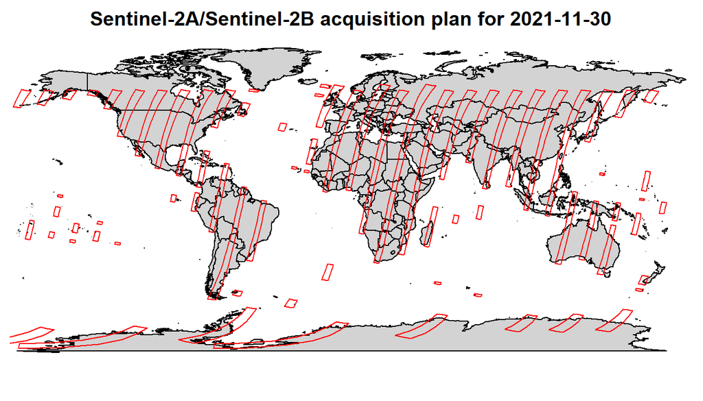

```r
library(maps)
maps::map("world", fill = TRUE, col = "lightgrey", mar = c(0.5, 0.5, 4, 0.5))
plot(sf::st_geometry(plan), border = "red", add = TRUE)
title(main = sprintf("%s acquisition plan for %s", paste(sat, collapse = "/"), day), line = 1L)
```

# Satellite overpasses

It is possible to get past and planned overpasses over an area/region of interest. We shall use the Luxembourg country shape as area of interest in our examples.

```r
roi <- system.file("extdata", "luxembourg.geojson", package = "spectator")
boundary <- sf::read_sf(roi, as_tibble = FALSE)
```

This functionality requires a valid API key. So we shall first get the API key from an environment variable or set it in any other suitable way.

```r
my_key <- Sys.getenv("spectator_earth_api_key")
```

We shall now look for Sentinel-2A and Sentinel-2B overpasses of Luxembourg for the following week (default time frame). We can use the shorthand notation to specify satellites of interest (see the help page for the `GetOverpasses` function).

```r
pass <- GetOverpasses(boundary, satellites = "S2", acquisitions = FALSE, api_key = my_key)
head(pass)
```

|  | id | acquisition | date | satellite | geometry |
| --- | --- | --- | --- | --- | --- |
| 1 | 160474714 | TRUE | 2021-11-28 10:47:00 | Sentinel-2A |  |
| 2 | 160522871 | FALSE | 2021-11-28 21:20:00 | Sentinel-2B |  |
| 3 | 162184127 | TRUE | 2021-11-30 10:37:00 | Sentinel-2B |  |
| 4 | 162138062 | TRUE | 2021-12-01 10:57:00 | Sentinel-2A |  |
| 5 | 162186219 | FALSE | 2021-12-01 21:29:00 | Sentinel-2B |  |
| 6 | 163847468 | TRUE | 2021-12-03 10:47:00 | Sentinel-2B |  |

The footprints of the overpasses can be plotted, here we use only the neighboring countries and show the region of interest in red.

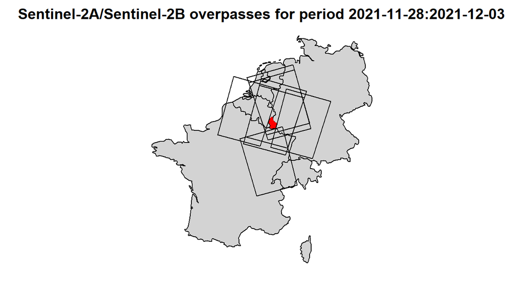

```r
library(maps)
days <- range(as.Date(pass$date))
satellites <- sort(unique(pass$satellite))
maps::map(database = "world", region = c("Belgium", "Netherlands", "Germany", "Luxembourg",
            "France", "Switzerland"), col = "lightgrey", fill = TRUE, mar = c(0.5, 0.5, 4, 0.5))
plot(sf::st_geometry(boundary), add = TRUE, col = "red", border = FALSE)
plot(sf::st_geometry(pass), add = TRUE)
title(main = sprintf("%s overpasses for period %s", paste(satellites, collapse = "/"),
                     paste(days, collapse = ":")), line = 1L)
```

We shall now look for Sentinel-1A and Sentinel-1B overpasses of Luxembourg for the previous week. We can use the use shorthand notation to specify satellites of interest (see the help page for the `GetOverpasses` function).

```r
pass <- GetOverpasses(boundary, satellites = "S-1",
                      days_before = 7, days_after = 0, acquisitions = TRUE)
head(pass)
```

|  | id | acquisition | date | satellite | geometry |
| --- | --- | --- | --- | --- | --- |
| 1 | 157099486 | TRUE | 2021-11-21 17:24:00 | Sentinel-1B |  |
| 2 | 157053395 | TRUE | 2021-11-22 17:17:00 | Sentinel-1A |  |
| 3 | 157101680 | TRUE | 2021-11-23 05:58:00 | Sentinel-1B |  |
| 4 | 158761362 | TRUE | 2021-11-23 17:08:00 | Sentinel-1B |  |
| 5 | 158714602 | TRUE | 2021-11-24 05:51:00 | Sentinel-1A |  |
| 6 | 158763556 | TRUE | 2021-11-25 05:42:00 | Sentinel-1B |  |

Again, we can plot the footprints of the overpasses, using only the neighboring countries and showing the region of interest in red.

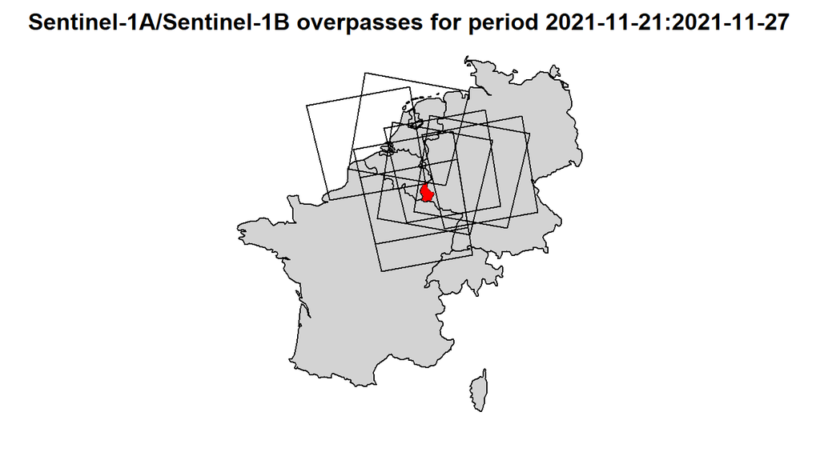

```r
days <- range(as.Date(pass$date))
satellites <- sort(unique(pass$satellite))
maps::map(database = "world", region = c("Belgium", "Netherlands", "Germany", "Luxembourg",
            "France", "Switzerland"), col = "lightgrey", fill = TRUE, mar = c(0.5, 0.5, 4, 0.5))
plot(sf::st_geometry(boundary), add = TRUE, col = "red", border = FALSE)
plot(sf::st_geometry(pass), add = TRUE)
title(main = sprintf("%s overpasses for period %s", paste(satellites, collapse = "/"),
                     paste(days, collapse = ":")), line = 1L)
```

# Plot overpasses calendar

Let’s try to get as much information as we can (past and future overpasses) about Sentinel-2A and Sentinel-2B overpasses of Luxembourg.

```r
pass <- GetOverpasses(boundary, satellites = "S-2", acquisitions = FALSE, api_key = my_key,
                      days_before = 99, days_after = 99)
```

As the acquisitions take place only in the middle of the day, we shall keep only the overpasses between 06:00 and 18:00.

```r
# we need these packages
library(sf)
library(lutz)
library(lubridate)
tz <- lutz::tz_lookup(sf::st_centroid(sf::st_geometry(boundary)), method = "accurate")
localtime <- lubridate::local_time(pass$date, tz = tz, units = "hours")
pass$acquisition <- localtime > 6 & localtime < 18
pass <- subset(pass, acquisition == TRUE)
```

We can now plot the nice calendar using the `calendR` package.

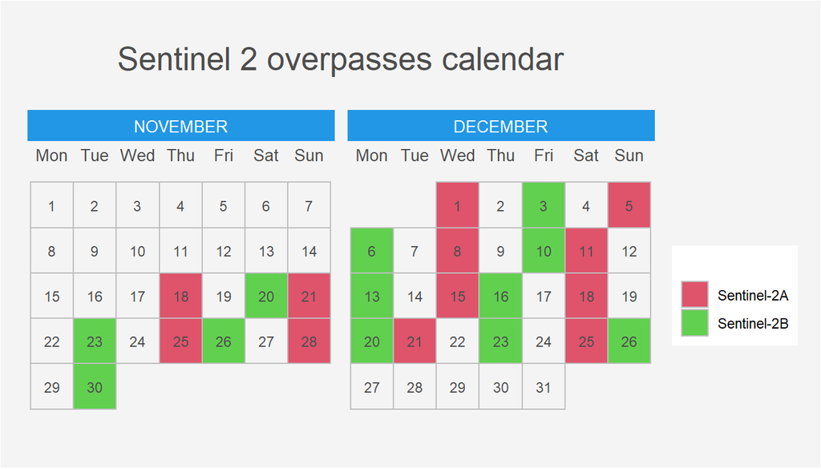

```r
# we need this package
library(calendR)
time_span <- range(as.Date(pass$date))
satellites <- sort(unique(pass$satellite))
first_date <- lubridate::floor_date(lubridate::ymd(time_span[1]), unit = "month")
last_date <- lubridate::ceiling_date(lubridate::ymd(time_span[2]), unit = "month") - 1
days <- first_date:last_date
passes <- as.Date(pass$date)
events <- rep(NA, length(days))
events[passes - first_date + 1] <- pass$satellite

# will use English month and day of week labels
ans <- Sys.setlocale(category = "LC_ALL", locale = "English")

calendR::calendR(start_date = first_date, end_date = last_date,
                 title = "Sentinel 2 overpasses calendar",
                 special.days = events,
                 special.col = 2:(length(satellites) + 1),
                 col = "grey",
                 mbg.col = 4,               # Color of the background of the names of the months
                 months.col = "white",      # Color text of the names of the months
                 bg.col = "#f4f4f4",        # Background color
                 start = "M",               # Start the weeks on Monday
                 legend.pos = "right")
```

# Show overpasses in a calendar app

We can also export the overpasses calendar as a calendar file (iCal or ICS file), which can be imported in any calendar management application. You could thus take the overpasses calendar with you in the calendar app of your smartphone, for example. We shall use the `calendar` package to generate the iCal file.

```r
# we need this package
library(calendar)

N <- nrow(pass)
lst <- vector(mode = "list", length = N)
for (i in 1:nrow(pass)) {
    x <- pass[i, ]
    lst[[i]] <- calendar::ic_event(uid = calendar::ic_guid(), start_time = x$date, end_time = x$date, summary = x$satellite)
}

cal <- calendar::ical(do.call(rbind, lst))
# cal[, "TZID"] <- tz
koords <- sf::st_coordinates(sf::st_centroid(sf::st_geometry(boundary, of_largest_polygon = FALSE)))
cal[, "LOCATION"] <- sprintf("(LAT:%f;LONG:%f)", koords[, "Y"], koords[, "X"])
calFile <- "overpasses.ics"
calendar::ic_write(cal, file = calFile)
```

We can now import this file in our preferred calendar management application, here Google calendar.

[figure not shown]

*A screen shot of Google calendar showing the Sentinel-2A and Sentinel-2B overpasses of Luxembourg.*

# Searching for images

We can query the archived images catalog to find available images for an area of interest (AOI). It can be done for images captured by Sentinel-1, Sentinel-2, Landsat-8 and Landsat-9 satellites. This functionality requires a valid API key. So we shall first get the API key from an environment variable or set it in any other suitable way.

```r
my_key <- Sys.getenv("spectator_earth_api_key")
```

Let’s say that our area of interest (AOI) is the New York City Central Park. We shall first read the contour from a GeoJSON file.

```r
roi <- system.file("extdata", "centralpark.geojson", package = "spectator")
boundary <- sf::read_sf(roi, as_tibble = FALSE)
```

Now we shall look for all Sentinel 2 images (both Sentinel-2A and Sentinel-2B) captured in May 2021. We shall use again the shorthand notation to specify satellites of interest (see the help page for the `GetOverpasses` function).

```r
catalog <- SearchImages(aoi = boundary, satellites = "S2",
                        date_from = "2021-05-01", date_to = "2021-05-30",
                        footprint = FALSE, api_key = my_key)
head(catalog, n = 20L)
```

|  | id | uuid | identifier | ingestion_date | begin_position_date | end_position_date | download_url | satellite | scene_id | cloud_cover_percentage | product_type |
| --- | --- | --- | --- | --- | --- | --- | --- | --- | --- | --- | --- |
| 1 | 23750237 | df602654-513b-4034-809d-b5535b394df6 | S2B_MSIL1C_20210527T153809_N0300_R011_T18TWL_20210527T192322 | 2021-05-27 20:55:29 | 2021-05-27 15:38:09 | 2021-05-27 15:38:09 | http://api.spectator.earth/imagery/23750237/files/ | Sentinel-2B | S2B_tile_20210527_18TWL_0 | 9.64 | S2MSI1C |
| 2 | 23721191 | 12fff8b5-0826-4ffa-b32b-1476e7a5cd53 | S2A_MSIL1C_20210525T154911_N0300_R054_T18TWL_20210525T210212 | 2021-05-25 21:57:38 | 2021-05-25 15:49:11 | 2021-05-25 15:49:11 | http://api.spectator.earth/imagery/23721191/files/ | Sentinel-2A | S2A_tile_20210525_18TWL_0 | 16.59 | S2MSI1C |
| 3 | 23674074 | 127acce9-abaf-4927-8085-f9585069b94e | S2A_MSIL1C_20210522T153911_N0300_R011_T18TWL_20210522T210059 | 2021-05-22 22:24:48 | 2021-05-22 15:39:11 | 2021-05-22 15:39:11 | http://api.spectator.earth/imagery/23674074/files/ | Sentinel-2A | S2A_tile_20210522_18TWL_0 | 100.00 | S2MSI1C |
| 4 | 23650011 | 8be7762d-e91c-4a84-a749-5bc88884a17a | S2B_MSIL1C_20210520T154809_N0300_R054_T18TWL_20210520T193636 | 2021-05-20 21:44:15 | 2021-05-20 15:48:09 | 2021-05-20 15:48:09 | http://api.spectator.earth/imagery/23650011/files/ | Sentinel-2B | S2B_tile_20210520_18TWL_0 | 29.52 | S2MSI1C |
| 5 | 23620104 | 87a67c2c-3892-49a5-88e7-2687fba3c631 | S2B_MSIL1C_20210517T153809_N0300_R011_T18TWL_20210517T192330 | 2021-05-19 03:42:29 | 2021-05-17 15:38:09 | 2021-05-17 15:38:09 | http://api.spectator.earth/imagery/23620104/files/ | Sentinel-2B | S2B_tile_20210517_18TWL_0 | 4.95 | S2MSI1C |
| 6 | 23580286 | cf1759cd-0af8-40b5-af42-f7579ae0cf5c | S2A_MSIL1C_20210515T154911_N0300_R054_T18TWL_20210515T194351 | 2021-05-16 18:36:26 | 2021-05-15 15:49:11 | 2021-05-15 15:49:11 | http://api.spectator.earth/imagery/23580286/files/ | Sentinel-2A | S2A_tile_20210515_18TWL_0 | 24.37 | S2MSI1C |
| 7 | 23534154 | 0711414d-109a-49e9-b80c-dd709777f232 | S2A_MSIL1C_20210512T153911_N0300_R011_T18TWL_20210512T193447 | 2021-05-13 00:58:45 | 2021-05-12 15:39:11 | 2021-05-12 15:39:11 | http://api.spectator.earth/imagery/23534154/files/ | Sentinel-2A | S2A_tile_20210512_18TWL_0 | 0.31 | S2MSI1C |
| 8 | 23513317 | 66f617de-97c6-49c5-aa40-92a81539a8e3 | S2B_MSIL1C_20210510T154809_N0300_R054_T18TWL_20210510T201052 | 2021-05-11 04:02:17 | 2021-05-10 15:48:09 | 2021-05-10 15:48:09 | http://api.spectator.earth/imagery/23513317/files/ | Sentinel-2B | S2B_tile_20210510_18TWL_0 | 87.25 | S2MSI1C |
| 9 | 23476646 | f88c7e74-6a99-45e9-a179-8e6fd7c4d68d | S2B_MSIL1C_20210507T153809_N0300_R011_T18TWL_20210507T191915 | 2021-05-07 20:44:40 | 2021-05-07 15:38:09 | 2021-05-07 15:38:09 | http://api.spectator.earth/imagery/23476646/files/ | Sentinel-2B | S2B_tile_20210507_18TWL_0 | 96.39 | S2MSI1C |
| 10 | 23453656 | 93f56793-129b-41cd-ba92-65ad851936c0 | S2A_MSIL1C_20210505T154901_N0300_R054_T18TWL_20210505T211100 | 2021-05-06 04:10:37 | 2021-05-05 15:49:01 | 2021-05-05 15:49:01 | http://api.spectator.earth/imagery/23453656/files/ | Sentinel-2A | S2A_tile_20210505_18TWL_0 | 99.49 | S2MSI1C |

[output cut: 1 more lines]

# Imagery files

To access the imagery files we have to use their ids. We shall concentrate on the image with minimal cloud coverage and get the corresponding id.

```r
best_id <- catalog[order(catalog$cloud_cover_percentage), ][1, "id"]
```

We can now retrieve the list of all available (downloadable) files for this id (the image with minimal cloud coverage).

```r
images <- GetImageryFilesList(best_id, api_key = my_key)
head(images, n = 20L)
```

|  | name | path | size |
| --- | --- | --- | --- |
| 1 | B01.jp2 | B01.jp2 | 3207245 |
| 2 | B02.jp2 | B02.jp2 | 92509539 |
| 3 | B03.jp2 | B03.jp2 | 97063884 |
| 4 | B04.jp2 | B04.jp2 | 98386739 |
| 5 | B05.jp2 | B05.jp2 | 28083414 |
| 6 | B06.jp2 | B06.jp2 | 31496749 |
| 7 | B07.jp2 | B07.jp2 | 32228879 |
| 8 | B08.jp2 | B08.jp2 | 118060960 |
| 9 | B09.jp2 | B09.jp2 | 3580391 |
| 10 | B10.jp2 | B10.jp2 | 1303521 |

[output cut: 4 more lines]

It should be noted that by default the function `GetImageryFilesList` lists only the full-sized images, not the other various auxiliary files such as image thumbnails, metadata, etc. You should set the argument `all` to `TRUE` to include them in the output.

We could now download the whole band 4 image tile for the image with the minimal cloud coverage using the code below. *Warning*: this is a very **BIG** file (98 386 739 bytes), so think twice before you start the download!

```r
from <- paste0(catalog[order(catalog$cloud_cover_percentage), ][1, "download_url"], "B04.jp2")
to <- "B04.jp2"
library(httr)
resp <- httr::GET(url = from, query = list(api_key = my_key))
writeBin(httr::content(resp), con = to)
```

# High-resolution images

We can also get a get the high-resolution images of the AOI (here Central Park) using the image id from the catalog. We shall use once again the id that corresponds to the with the minimal cloud coverage. One can request one or three bands, to get the monochrome or color (RGB) image. The Sentinel-2 RGB bands are 4, 3, and 2, respectively (source: https://en.wikipedia.org/wiki/Sentinel-2#Spectral_bands).

```r
img <- GetHighResolutionImage(aoi = boundary, id = best_id, bands = c(4, 3, 2),
                              width = 600, height = 950,
                              file = tempfile(pattern = "img", fileext = ".jpg"),
                              api_key = my_key)
```

##### High-resolution image

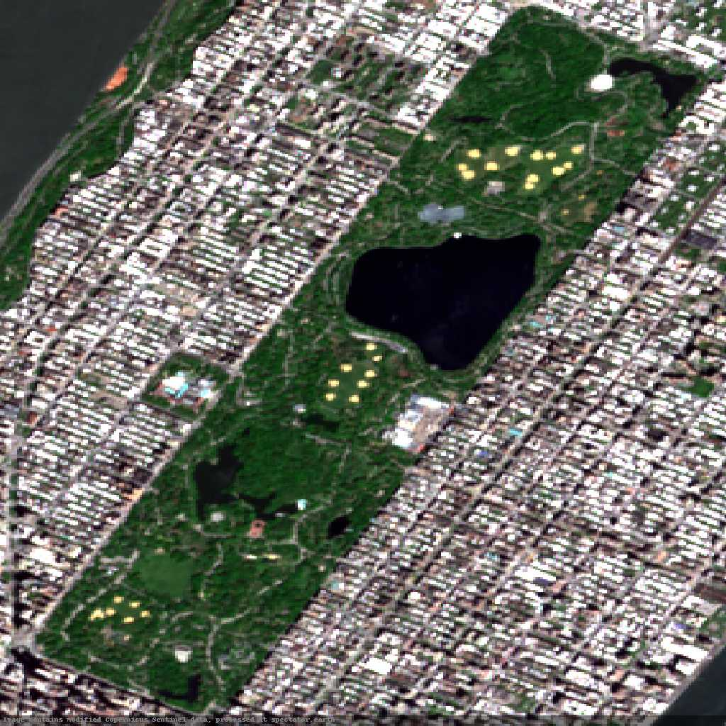

*Sentinel-2 image of Central Park, New York City on May 12, 2021.*

*Compiled on 2021-11-28 20:21:48.*